# Datasets from UCDP and PRIO

Joe Hasell

24/02/2022

# Data since 1989

The aim is to get a dataset of total deaths by year, entity (country*, region, world), and type of violence.

UCDP provides two kinds of data that can be used here.

## The georeferenced data (by event-dyad)

The first is it’s ‘Georeferenced’ dataset, which is structured by event (each row relates a particular bombing or raid in a certain place).

See the codebook here: https://ucdp.uu.se/downloads/ged/ged211.pdf

For deaths the primary focus will be on the `best` column (which is “The best (most likely) estimate of total fatalities resulting from an event.”) But I will also prepare aggregate data for the `low` and `high` deaths estimates.

An advantage of this dataset is that the place where the event happened is coded (local, country and region level).

#### Note on countries

Because the dataset only includes events with deaths (not the absence of events), after aggregating we will me missing observations for countries/years where there were no conflict deaths. UCDP aims to be complete global coverage: “GED 21.1 is a global dataset that covers the world between 1989-01-01 and 2020-12-31.” So any country-years with no deaths in this dataset needs to be given an entry of zero, rather than NA.

It requires some care however to make sure that we’re using the same ‘state system’ as the data is coded in. (For instance we shouldn’t code a 0 for Ukraine in 1990 because it didn’t exist and is included in ‘Russia (Soviet Union)’).

I will use the `country_id` which refer to the Gleditsch and Ward (G&W) state system. I will then ‘fill in the blanks’ based on the G&W system, and only then convert to OWID entities.

Because of the urgency to update, for now I won’t do this step. I will just aggregate at the region and conflict type level. And then I will come back to add the country-level data.

Let’s pull in the data and inspect.

```r
df_ged<- read.csv("original/UCDP Disaggregated datasets since 1989/ged211.csv")

kable(head(df_ged))
```

| id | relid | year | active_year | code_status | type_of_violence | conflict_dset_id | conflict_new_id | conflict_name | dyad_dset_id | dyad_new_id | dyad_name | side_a_dset_id | side_a_new_id | side_a | side_b_dset_id | side_b_new_id | side_b | number_of_sources | source_article | source_office | source_date | source_headline | source_original | where_prec | where_coordinates | where_description | adm_1 | adm_2 | latitude | … |
| --- | --- | --- | --- | --- | --- | --- | --- | --- | --- | --- | --- | --- | --- | --- | --- | --- | --- | --- | --- | --- | --- | --- | --- | --- | --- | --- | --- | --- | --- | --- |
| 244657 | IRQ-2017-1-524-322 | 2017 | 1 | Clear | 1 | 259 | 259 | Iraq: Government | 524 | 524 | Government of Iraq - IS | 116 | 116 | Government of Iraq | 234 | 234 | IS | 3 | “Agence France Presse,2017-08-01,Attackers target Shiite mosque in Afghanistan’s Herat”;“Agence France Presse,2017-08-01,At least 20 killed in Shiite mosque attack in Afghanistan’s Herat”;“Pajhwok New… | Agence France Presse;Agence France Presse;Pajhwok News | 2017-08-01;2017-08-01;2017-07-31 | Attackers target Shiite mosque in Afghanistan’s Herat;At least 20 killed in Shiite mosque attack in Afghanistan’s Herat;Assailants among 6 killed in Iraq Embassy attack | IS, interior ministry, security source | 1 | Kabul city | Iraqi embassy in Kabul | Kabul province | Kabul district | 34.53109 | … |
| 132140 | AFG-1989-1-411-2 | 1989 | 1 | Clear | 1 | 333 | 333 | Afghanistan: Government | 724 | 724 | Government of Afghanistan - Jam’iyyat-i Islami-yi Afghanistan | 130 | 130 | Government of Afghanistan | 292 | 292 | Jam’iyyat-i Islami-yi Afghanistan | -1 | The Times 13 Jan 1989 “Missiles and tea breaks for rebels;Afghanistan |  |  |  | Rebel source | 4 | Nangarhar province | Nangarhar province | Nangarhar province |  | 34.33333 | … |
| 130364 | AFG-1989-1-411-37 | 1989 | 1 | Clear | 1 | 333 | 333 | Afghanistan: Government | 724 | 724 | Government of Afghanistan - Jam’iyyat-i Islami-yi Afghanistan | 130 | 130 | Government of Afghanistan | 292 | 292 | Jam’iyyat-i Islami-yi Afghanistan | -1 | R 18 Jan 1989 “KABUL REPORTS HUNDREDS OF REBEL CASUALTIES IN KUNDUZ PROVINCE. |  |  |  | Kabul radio (monitored in Islamabad) | 4 | Kunduz province | Kunduz province | Kunduz province |  | 36.75000 | … |
| 130359 | AFG-1989-1-411-4 | 1989 | 1 | Clear | 1 | 333 | 333 | Afghanistan: Government | 724 | 724 | Government of Afghanistan - Jam’iyyat-i Islami-yi Afghanistan | 130 | 130 | Government of Afghanistan | 292 | 292 | Jam’iyyat-i Islami-yi Afghanistan | -1 | Reuters 24 Jan 1989 “AFGHANS KILL NEARLY 400 REBELS, TASS SAYS.” /The Washington Post 27 Jan 1989 “Rebels Send Food Convoy To Kabul;U.S. Orders Embassy Evacuated, Closed” /The Toronto Star 28 Jan 1989… |  |  |  | Tass news agency /Western diplomats quoting witnesses /Rebel spokesman | 1 | Salang pass | Salang pass (on the main highway linking Kabul with the Soviet border) | Baghlan province | Khinjan district | 35.31583 | … |
| 133883 | AFG-1989-1-411-39 | 1989 | 1 | Clear | 1 | 333 | 333 | Afghanistan: Government | 724 | 724 | Government of Afghanistan - Jam’iyyat-i Islami-yi Afghanistan | 130 | 130 | Government of Afghanistan | 292 | 292 | Jam’iyyat-i Islami-yi Afghanistan | -1 | The Sunday Times 5 Feb 1989 “The Russians move out…;Withdrawal from Afghanistan |  |  |  | Military spokesman | 1 | Kabul city | Kabul city | Kabul province | Kabul district | 34.53109 | … |
| 133874 | AFG-1989-1-411-6 | 1989 | 1 | Clear | 1 | 333 | 333 | Afghanistan: Government | 724 | 724 | Government of Afghanistan - Jam’iyyat-i Islami-yi Afghanistan | 130 | 130 | Government of Afghanistan | 292 | 292 | Jam’iyyat-i Islami-yi Afghanistan | -1 | St. Louis Post-Dispatch 1 Feb 1989 “JET CARRYING U.S. ENVOYS NEARLY HITS SOVIET PLANE |  |  |  | Rebel spokesman | 2 | Salang tunnel | Salang tunnel (near, villages near the main Soviet withdrawal route, Salang tunnel) | Baghlan province | Khinjan district | 35.31603 | … |

A quick check on key variables:

```r
#best (best deaths estimate:)
min(df_ged$best)
```

```
## [1] 0
```

```r
max(df_ged$best)
```

```
## [1] 48183
```

```r
sum(is.na(df_ged$best))
```

```
## [1] 0
```

```r
#low (low deaths estimate:)
min(df_ged$low)
```

```
## [1] 0
```

```r
max(df_ged$low)
```

```
## [1] 48183
```

```r
sum(is.na(df_ged$low))
```

```
## [1] 0
```

```r
#high (high deaths estimate:)
min(df_ged$high)
```

```
## [1] 0
```

```r
max(df_ged$high)
```

```
## [1] 75000
```

```r
sum(is.na(df_ged$high))
```

```
## [1] 0
```

```r
#year:
min(df_ged$year)
```

```
## [1] 1989
```

```r
max(df_ged$year)
```

```
## [1] 2020
```

```r
sum(is.na(df_ged$year))
```

```
## [1] 0
```

```r
#type_of_violence:
min(df_ged$type_of_violence)
```

```
## [1] 1
```

```r
max(df_ged$type_of_violence)
```

```
## [1] 3
```

```r
sum(is.na(df_ged$type_of_violence))
```

```
## [1] 0
```

```r
# country (where the event happened)
sum(is.na(df_ged$country))
```

```
## [1] 0
```

```r
sum(df_ged$country == "")
```

```
## [1] 0
```

```r
# country_id - using the Gleditsch and Ward IDs
min(df_ged$country_id)
```

```
## [1] 2
```

```r
max(df_ged$country_id)
```

```
## [1] 940
```

```r
sum(is.na(df_ged$country_id))
```

```
## [1] 0
```

I rename some variables to make interactions with the other datasets used below a bit easier.

```r
df_ged<- df_ged %>%
  rename(type = type_of_violence)
```

And then let’s aggregate the different deaths estimates by `year` `region` and `type`

```r
df_year_region_type_agg<- df_ged %>%
  group_by(year, region, type) %>%
  summarise(deaths_best = sum(best),
            deaths_low = sum(low),
            deaths_high = sum(high))
```

I’ll recode the type of violence categorical variable according to the codebook.

```r
df_year_region_type_agg<- df_year_region_type_agg %>%
  mutate(type = recode(type,
                                   `1` = "State-based conflict",
                                   `2` = "Non-state conflict",
                                   `3` = "One-sided violence"))
```

And I’ll add an “All types of violence” aggregate that sums across the three types of violence, as well as a world total for each of the types of violence.

```r
# add 'all' type total

all_types_by_region_total<- df_year_region_type_agg %>%
  group_by(year, region, ) %>%
  summarise(deaths_best = sum(deaths_best),
            deaths_low = sum(deaths_low),
            deaths_high = sum(deaths_high)) %>%
  mutate(type = "All types of violence")
df_year_region_type_agg<- rbind(df_year_region_type_agg, all_types_by_region_total)


# Add World total (by type)

world_total_by_type<- df_year_region_type_agg %>%
  group_by(year, type) %>%
  summarise(deaths_best = sum(deaths_best),
            deaths_low = sum(deaths_low),
            deaths_high = sum(deaths_high)) %>%
  mutate(region = "World")
df_year_region_type_agg<- rbind(df_year_region_type_agg, world_total_by_type)
```

This is what the final aggregates look like from the geo-referenced data:

```r
kable(head(df_year_region_type_agg))
```

| year | region | type | deaths_best | deaths_low | deaths_high |
| --- | --- | --- | --- | --- | --- |
| 1989 | Africa | State-based conflict | 34546 | 34541 | 47433 |
| 1989 | Africa | Non-state conflict | 2524 | 2524 | 3573 |
| 1989 | Africa | One-sided violence | 3538 | 3536 | 9428 |
| 1989 | Americas | State-based conflict | 8715 | 8386 | 11158 |
| 1989 | Americas | Non-state conflict | 12 | 11 | 12 |
| 1989 | Americas | One-sided violence | 726 | 363 | 1149 |

#### Export aggrgeated geo-referenced data for OWID grapher

For the time being, I’ll only upload the ‘best’ deaths data. But my plan is to add visualizations showing the range between the low, high and best estimates.

Here I drop the high/low deaths estimates and then spread to wide format where each variable is the the deaths estimate for a type of conflict.

```r
df_year_region_type_agg<- df_year_region_type_agg %>%
  select(-c(deaths_low, deaths_high)) %>%
  mutate(type = paste0("Deaths in ", tolower(type))) %>%
  pivot_wider(names_from = "type", values_from = "deaths_best") %>%
  rename(entity = region)
```

Export as csv

```r
write.csv(df_year_region_type_agg, "output/Violent deaths in conflicts and one-sided violence since 1989, by region and type of violence (PRIO and UCDP).csv", row.names = FALSE)
```

### Compare with by year-dyad datasets for the three types of violence

The second kind of data for this period is a trio of datasets, one for each type of violence: ‘State-based’, ‘Non-state’, ‘One-sided’.

These are organised by year and dyad (i.e. pair of participants).

Let’s pull in an inspect the data for each of the three datasets.

Notice that the equivalent `best` deaths variable have different names in these datasets: `bd_best` in the case of state-based (‘bd’ standing for ‘battle deaths’) and `best_fatality_estimate` in the case of non-state and one-sided violence. This does not signify any conceptual difference (the difference lies only in the participants, not in the concept of death).

State-based (See codebook: https://ucdp.uu.se/downloads/brd/ucdp-brd-codebook-211.pdf)

```r
df_state_based<- read.csv("original/UCDP Yearly datasets since 1989/ucdp-brd-dyadic-211.csv")

kable(head(df_state_based))
```

| conflict_id | dyad_id | location_inc | side_a | side_a_id | side_a_2nd | side_b | side_b_id | side_b_2nd | incompatibility | territory_name | year | bd_best | bd_low | bd_high | type_of_conflict | battle_location | gwno_a | gwno_a_2nd | gwno_b | gwno_b_2nd | gwno_loc | gwno_battle | region | version |
| --- | --- | --- | --- | --- | --- | --- | --- | --- | --- | --- | --- | --- | --- | --- | --- | --- | --- | --- | --- | --- | --- | --- | --- | --- |
| 11447 | 10006 | Ethiopia | Government of Ethiopia | 97 |  | IGLF | 1115 |  | 1 | Hararghe | 1991 | 100 | 100 | 100 | 3 | Ethiopia | 530 |  |  |  | 530 | 530 | 4 | 21.1 |
| 372 | 10054 | Mali | Government of Mali | 72 |  | FPLA | 934 |  | 1 | Azawad | 1991 | 59 | 3 | 138 | 3 | Mali | 432 |  |  |  | 432 | 432 | 4 | 21.1 |
| 283 | 10509 | DR Congo (Zaire) | Government of DR Congo (Zaire) | 89 | Government of Malawi, Government of South Africa, Government of Tanzania | APCLS | 1200 |  | 2 |  | 2013 | 135 | 125 | 180 | 4 | DR Congo (Zaire) | 490 | 553, 560, 510 |  |  | 490 | 490 | 4 | 21.1 |
| 283 | 10509 | DR Congo (Zaire) | Government of DR Congo (Zaire) | 89 | Government of Malawi, Government of South Africa, Government of Tanzania | APCLS | 1200 |  | 2 |  | 2014 | 29 | 26 | 29 | 4 | DR Congo (Zaire) | 490 | 553, 560, 510 |  |  | 490 | 490 | 4 | 21.1 |
| 283 | 10509 | DR Congo (Zaire) | Government of DR Congo (Zaire) | 89 | Government of Malawi, Government of South Africa, Government of Tanzania | APCLS | 1200 |  | 2 |  | 2020 | 48 | 48 | 48 | 4 | DR Congo (Zaire) | 490 | 553, 560, 510 |  |  | 490 | 490 | 4 | 21.1 |
| 383 | 10516 | Turkey | Government of Turkey | 115 |  | TAK | 2034 |  | 2 |  | 2016 | 111 | 109 | 112 | 3 | Turkey | 640 |  |  |  | 640 | 640 | 2 | 21.1 |

Non-state (See codebook: https://ucdp.uu.se/downloads/nsos/ucdp-nonstate-211.pdf)

```r
df_non_state<- read.csv("original/UCDP Yearly datasets since 1989/ucdp-nonstate-211.csv")

kable(head(df_non_state))
```

| conflict_id | dyad_id | org | side_a_name | side_a_name_fulltext | side_a_name_mothertongue | side_a_id | side_a_components | side_a_2nd | gwno_a_2nd | side_b_name | side_b_name_fulltext | side_b_name_mothertongue | side_b_id | side_b_components | side_b_2nd | gwno_b_2nd | start_date | start_prec | start_date2 | start_prec2 | ep_end | ep_end_date | ep_end_prec | year | best_fatality_estimate | low_fatality_estimate | high_fatality_estimate | location | gwno_location | … |
| --- | --- | --- | --- | --- | --- | --- | --- | --- | --- | --- | --- | --- | --- | --- | --- | --- | --- | --- | --- | --- | --- | --- | --- | --- | --- | --- | --- | --- | --- | --- |
| 9637 | 10247 | 3 | Konianke | Konianke | Konianke | 1713 |  |  | NA | Kpelle | Kpelle | Kpelle | 1141 |  |  |  | 2013-07-15 | 1 | 2013-07-17 | 2 | 1 | 2013-07-17 | 2 | 2013 | 98 | 98 | 98 | Guinea | 438 | … |
| 9691 | 10301 | 3 | Northern Sudanese | Northern Sudanese | Northern Sudanese | 1972 |  |  | NA | Southern Sudanese | Southern Sudanese | Southern Sudanese | 1973 |  |  |  | 2005-08-03 | 2 | 2005-08-03 | 2 | 1 | 2005-08-03 | 2 | 2005 | 130 | 130 | 130 | Sudan | 625 | … |
| 9708 | 10318 | 3 | Habaniya | Habaniya | Habaniya | 615 |  |  | NA | Salamat Baggara | Salamat Baggara | Salamat Baggara | 994 |  |  |  | 2007-01-08 | 1 | 2017-05-10 | 3 | 1 | 2017-05-10 | 3 | 2017 | 41 | 41 | 41 | Sudan | 625 | … |
| 9940 | 10550 | 3 | Bete | Bete | Bété | 1296 |  |  | NA | Senufo | Senufo | Senufo | 1111 |  |  |  | 2002-12-31 | 5 | 2004-12-23 | 1 | 1 | 2004-12-23 | 1 | 2004 | 25 | 24 | 29 | Ivory Coast | 437 | … |
| 10066 | 10676 | 1 | Hizb-i Wahdat | Unity Party | Hizb-i Wahdat | 300 |  |  | NA | Junbish-i Milli-yi Islami | National Islamic Movement | Junbish-i Milli-yi Islami | 302 |  |  |  | 1995-02-20 | 2 | 1998-03-15 | 2 | 1 | 1998-03-19 | 1 | 1998 | 101 | 101 | 101 | Afghanistan | 700 | … |
| 10072 | 10682 | 1 | Forces of Sayed Mansur Naderi | Forces of Sayed Mansur Naderi | Forces of Sayed Mansur Naderi | 2518 |  |  | NA | Hizb-i Islami-yi Afghanistan | Islamic Party of Afghanistan | Hizb-i Islami-yi Afghanistan | 299 |  |  |  | 1995-09-30 | 3 | 1995-10-29 | 1 | 1 | 1995-10-29 | 1 | 1995 | 40 | 40 | 40 | Afghanistan | 700 | … |

One-sided (See codebook: https://ucdp.uu.se/downloads/nsos/ucdp-onesided-211.pdf)

```r
df_one_sided<- read.csv("original/UCDP Yearly datasets since 1989/ucdp-onesided-211.csv")

kable(head(df_one_sided))
```

| conflict_id | dyad_id | actor_id | coalition_components | actor_name | actor_name_fulltext | actor_name_mothertongue | year | best_fatality_estimate | low_fatality_estimate | high_fatality_estimate | is_government_actor | location | gwno_location | gwnoa | region | version |
| --- | --- | --- | --- | --- | --- | --- | --- | --- | --- | --- | --- | --- | --- | --- | --- | --- |
| 533 | 1000 | 367 |  | Forces of the Caucasus Emirate | Forces of the Caucasus Emirate | Имарат Кавказ / Имар Кавказ/ Кавказский Эмират | 2010 | 58 | 58 | 60 | 0 | Russia (Soviet Union) | 365 | NA | 1 | 21.1 |
| 533 | 1000 | 367 |  | Forces of the Caucasus Emirate | Forces of the Caucasus Emirate | Имарат Кавказ / Имар Кавказ/ Кавказский Эмират | 2011 | 40 | 39 | 45 | 0 | Russia (Soviet Union) | 365 | NA | 1 | 21.1 |
| 533 | 1000 | 367 |  | Forces of the Caucasus Emirate | Forces of the Caucasus Emirate | Имарат Кавказ / Имар Кавказ/ Кавказский Эмират | 2013 | 40 | 40 | 43 | 0 | Russia (Soviet Union) | 365 | NA | 1 | 21.1 |
| 534 | 1001 | 368 |  | DHD - BW | Dima Halam Daogah - Black Widow faction | Dima Halam Daogah - Black Widow faction | 2008 | 35 | 35 | 37 | 0 | India | 750 | NA | 3 | 21.1 |
| 535 | 1002 | 373 |  | BLTF | Bodo Liberation Tiger Force | n/a | 1996 | 37 | 37 | 43 | 0 | India | 750 | NA | 3 | 21.1 |
| 535 | 1002 | 373 |  | BLTF | Bodo Liberation Tiger Force | n/a | 1998 | 31 | 31 | 33 | 0 | India | 750 | NA | 3 | 21.1 |

#### A note on location within the non-georeferenced datasets

In these datasets, the location variables (`location` and `region`) do not (necessarily) refer to the actual place where the deaths occurred. They refer to the location of the ‘incompatibility’ that delineates the conflict (i.e. an argument over territory or of who should be in charge of a place.)

#### Calculate total deaths in the non-georeferenced data

Let’s sum up the non-georeferenced datasets…

```r
df_state_based_totals<- df_state_based%>%
  select(year, bd_best) %>%
  group_by(year) %>%
  summarise(deaths_annual_data = sum(bd_best)) %>%
  mutate(type_of_violence = "State-based conflict")

df_non_state_totals<- df_non_state %>%
  select(year, best_fatality_estimate) %>%
  group_by(year) %>%
  summarise(deaths_annual_data = sum(best_fatality_estimate)) %>%
  mutate(type_of_violence = "Non-state conflict")

df_one_sided_totals<- df_one_sided %>%
  select(year, best_fatality_estimate) %>%
  group_by(year) %>%
  summarise(deaths_annual_data = sum(best_fatality_estimate)) %>%
  mutate(type_of_violence = "One-sided violence")
```

…And then merge into a single dataset, arranged by year and type of violence.

```r
df_annual_data<- rbind(df_state_based_totals, df_non_state_totals)

df_annual_data<- rbind(df_annual_data, df_one_sided_totals)

kable(head(df_annual_data))
```

| year | deaths_annual_data | type_of_violence |
| --- | --- | --- |
| 1989 | 54304 | State-based conflict |
| 1990 | 79939 | State-based conflict |
| 1991 | 70288 | State-based conflict |
| 1992 | 48999 | State-based conflict |
| 1993 | 36953 | State-based conflict |
| 1994 | 33469 | State-based conflict |

And let’s add an “All types of violence” type which sums across the three

```r
# calculate sum
df_annual_data_total<- df_annual_data %>%
  group_by(year) %>%
  summarise(deaths_annual_data = sum(deaths_annual_data)) %>%
  mutate(type_of_violence = "All types of violence")

# merge back in
df_annual_data<- rbind(df_annual_data, df_annual_data_total)
```

#### Comparison of aggregate deaths between the georeferenced and non-georeferenced data

In the [georeferenced data codebook](https://ucdp.uu.se/downloads/ged/ged211.pdf) it says: “Note that the release of UCDP GED is not synchronized perfectly with the above datasets, thus data discrepancies may appear due to data revisions.”

To see the discrepancy, I merge the World totals from the georeferenced data with the totals from the non-georeferenced data just calculated (both are arranged by year type of violence).

```r
check<- left_join(world_total_by_type %>% select(year, type, deaths_best) %>%
                    rename(type_of_violence = type),
                  df_annual_data) %>%
  mutate(diff = (deaths_annual_data - deaths_best)/deaths_best)
```

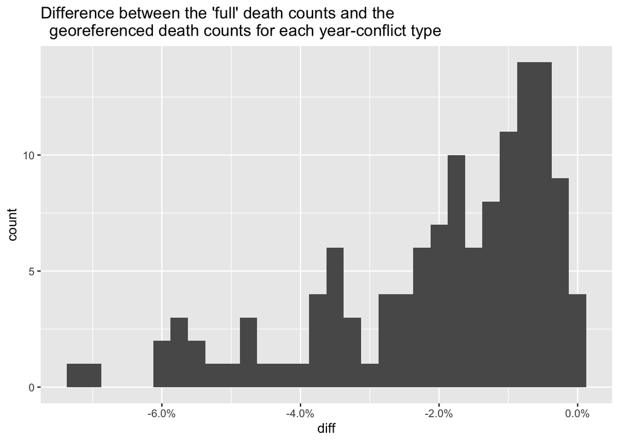

```r
# histogram
ggplot(check, aes(x=diff)) +
  geom_histogram() +
  scale_x_continuous(labels = scales::percent) +
  ggtitle("Difference between the 'full' death counts and the \n  georeferenced death counts for each year-conflict type")
```

### Conclusion - let’s use the georeferenced data for all post-1989 datasets

Prior to this update, our post-1989 UCDP charts were making use of the trio of non-georeferenced datasets - with the downside about the location I mentioned earlier (resulting in quite long and complex chart subtitles and notes).

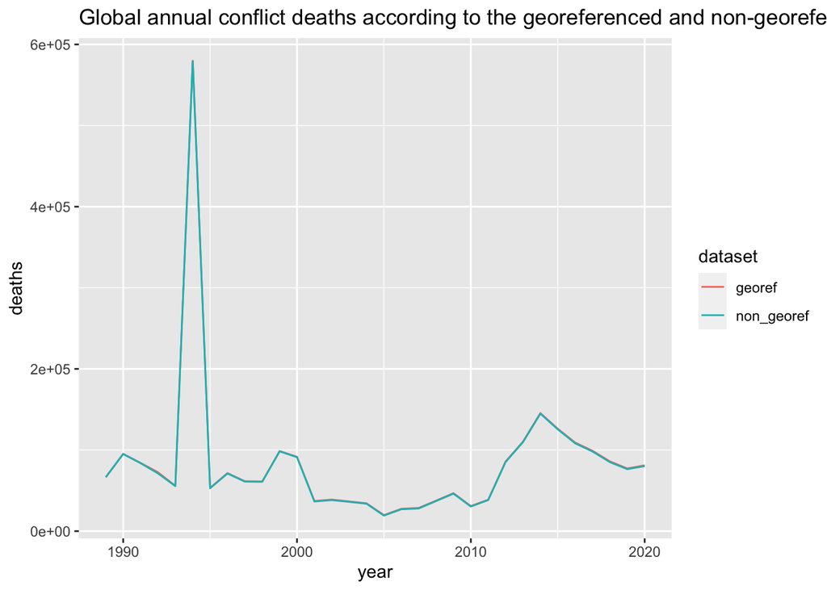

```r
check %>%
  filter(type_of_violence=="All types of violence") %>%
  select(year, deaths_best, deaths_annual_data) %>%
  rename(georef = deaths_best,
         non_georef = deaths_annual_data) %>%
  pivot_longer(cols = !year, names_to = "dataset", values_to = "deaths") %>%
  ggplot(aes(x=year, y=deaths, colour = dataset)) +
  geom_line() +
  ggtitle("Global annual conflict deaths according to the georeferenced and non-georeferenced data from UCDP")
```

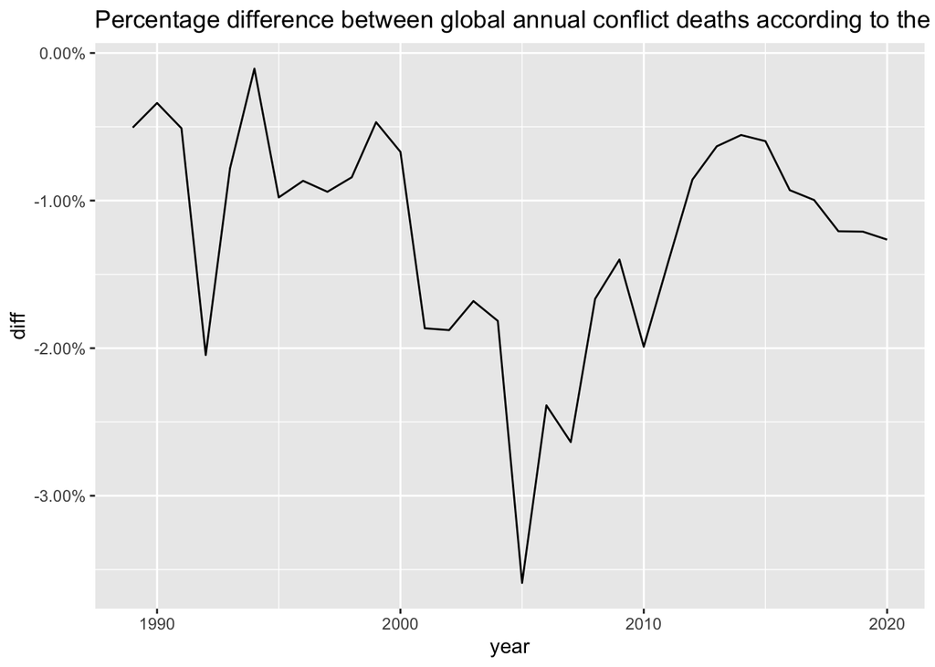

```r
check %>%
  filter(type_of_violence=="All types of violence") %>%
  ggplot(aes(x= year, y = diff)) +
  geom_line() +
  scale_y_continuous(labels = scales::percent) +
  ggtitle("Percentage difference between global annual conflict deaths according to the georeferenced and non-georeferenced data from UCDP")
```

# State-based conflict deaths since 1946

### Overview

To produce a series of conflict deaths since 1946 we will stitch together:

1. the UCDP Battle-Related Deaths Dataset (the ‘state-based’ component of the three non-georeferenced datasets from 1989 introduced above).
2. Earlier data for the same concept produced by PRIO that is no longer maintained.

UCDP’s BRD dataset is made to be compatible with the UCDP/PRIO Armed Conflict Dataset (ACD). The latter is a dataset just of conflicts that goes back to 1946, but does not include estimates of deaths. So the UCDP’s ‘state-based’ conflict death series from 1989 is a bit like a ‘bolt-on’ that adds deaths estimates onto the framework of conflicts produced in the ACD dataset.

UCDP does not maintain a dataset of conflict deaths prior to 1989.

However an older dataset of battle deaths that aimed to the same thing (for a much older version of the ACD data) was produced by PRIO with data available from 1946.

The problem is that 1) it is old (ends in 2008) 2) it is no longer being maintained (not since 2008) and 3) the conflict framework is now somewhat out of step with the latest ACD dataset (for instance there is a different conflict ID system).

Nonetheless in terms of total deaths in any given year, the older PRIO data is likely to be fairly complete an accurate for the years it covers, especially prior to 1989. (i.e. it seems safe to assume that not a lot of new information will have surfaced since 2008 about conflicts prior to 1989). So it’s reasonable to stitch these aggregate deaths from these two datasets together.

#### A note on location within these two (non-georeferenced) datasets

The same note on the way location variables are coded mentioned above applies to these two datasets.

In these datasets, the location variables (`location` and `region`) do not (necessarily) refer to the actual place where the deaths occurred. They refer to the location of the ‘incompatibility’ that delineates the conflict (i.e. an argument over territory or of who should be in charge of a place.)

Unlike the period since 1989, there is however there no alternative geo-referenced data to turn to.

We have to just handle this problem and explain it well in the metadata for the resulting OWID dataset.

For this reason we will only make use of `region` entities (since the issue will be less acute in the at the level of regions).

#### A note on conflict type

This data all falls into the ‘state-based’ type of violence, disucssed in relation to the 1989 data above.

But there is a sub-classification denoting whether it’s a civil conflict, imperial conflict etc. (The same classification is also used in the more recent UCDP BRD dataset).

### Wrangling

Pull in PRIO data (1946-2008)

```r
df_prio<- read.csv("original/PRIO/PRIO Battle Deaths Dataset 3.1.csv")
```

Rename a few variables to make matching to UCDP later more straightforward.

```r
df_prio<- df_prio %>%
  rename(bd_low = bdeadlow,
         bd_high = bdeadhig,
         bd_best = bdeadbes)
```

As before, the deaths variable we will use is the ‘best estimate’ But unlike the maintained UCDP datasets, this is sometimes coded as missing (`bd_best`=-999).

```r
browse_missing_best_estimates<- df_prio %>%
  filter(bd_best == -999)

kable(head(browse_missing_best_estimates))
```

| id | year | bd_low | bd_high | bd_best | annualdata | source | bdversion | location | sidea | sidea2nd | sideb | sideb2nd | incomp | terr | int | cumint | type | startdate | startprec | startdate2 | startprec2 | epend | ependdate | ependprec | gwnoa | gwnoa2nd | gwnob | gwnob2nd | gwnoloc | … |
| --- | --- | --- | --- | --- | --- | --- | --- | --- | --- | --- | --- | --- | --- | --- | --- | --- | --- | --- | --- | --- | --- | --- | --- | --- | --- | --- | --- | --- | --- | --- |
| 1 | 1952 | 450 | 3000 | -999 | 2 | 1 | 3.1 | Bolivia | Bolivia |  | MNR |  | 2 |  | 1 | 1 | 3 | 01/06/1946 | 4 | 09/04/1952 | 1 | 1 | 12/04/1952 | -99 | 145 |  |  |  | 145 | … |
| 2 | 1946 | 25 | 999 | -999 | 0 | 0 | 3.1 | Cambodia | France |  | Khmer Issarak |  | 1 | Cambodia | 1 | 0 | 1 | 01/08/1946 | 3 | 01/08/1946 | 3 | 0 |  | NA | 220 |  |  |  | 811 | … |
| 2 | 1947 | 25 | 999 | -999 | 0 | 0 | 3.1 | Cambodia | France |  | Khmer Issarak |  | 1 | Cambodia | 1 | 0 | 1 | 01/08/1946 | 3 | 01/08/1946 | 3 | 0 |  | NA | 220 |  |  |  | 811 | … |
| 2 | 1948 | 25 | 999 | -999 | 0 | 0 | 3.1 | Cambodia | France |  | Khmer Issarak |  | 1 | Cambodia | 1 | 0 | 1 | 01/08/1946 | 3 | 01/08/1946 | 3 | 0 |  | NA | 220 |  |  |  | 811 | … |
| 2 | 1949 | 25 | 999 | -999 | 0 | 0 | 3.1 | Cambodia | France |  | Khmer Issarak |  | 1 | Cambodia | 1 | 0 | 1 | 01/08/1946 | 3 | 01/08/1946 | 3 | 0 |  | NA | 220 |  |  |  | 811 | … |
| 2 | 1950 | 25 | 999 | -999 | 0 | 0 | 3.1 | Cambodia | France |  | Khmer Issarak |  | 1 | Cambodia | 1 | 0 | 1 | 01/08/1946 | 3 | 01/08/1946 | 3 | 0 |  | NA | 220 |  |  |  | 811 | … |

In fact that’s true of about 40% the observations.

```r
df_prio_check_missing<- df_prio %>%
  mutate(best_missing = if_else(bd_best == -999,
                                1,
                                0)) %>%
  mutate(high_estimate_bracket = cut(bd_high,
              breaks=c(0, 1000, 10000, 100000, max(df_prio$bd_high)),
              labels=c("<1K", "1K-10K", "10K-100K", ">100K")))


missing_best_deaths_est_by_range<- df_prio_check_missing %>%
  group_by(high_estimate_bracket, best_missing) %>%
  summarise(n=n()) %>%
  pivot_wider(names_from = "best_missing", values_from = "n") %>%
  mutate(share_missing = `1`/(`1` + `0`))
kable(missing_best_deaths_est_by_range)
```

| high_estimate_bracket | 0 | 1 | share_missing |
| --- | --- | --- | --- |
| <1K | 603 | 448 | 0.4262607 |
| 1K-10K | 414 | 262 | 0.3875740 |
| 10K-100K | 141 | 57 | 0.2878788 |
| >100K | 28 | 4 | 0.1250000 |

Let’s take a look at some of those very big events with missing

```r
kable(df_prio_check_missing %>% filter(best_missing == 1, high_estimate_bracket == ">100K"))
```

| id | year | bd_low | bd_high | bd_best | annualdata | source | bdversion | location | sidea | sidea2nd | sideb | sideb2nd | incomp | terr | int | cumint | type | startdate | startprec | startdate2 | startprec2 | epend | ependdate | ependprec | gwnoa | gwnoa2nd | gwnob | gwnob2nd | gwnoloc | … |
| --- | --- | --- | --- | --- | --- | --- | --- | --- | --- | --- | --- | --- | --- | --- | --- | --- | --- | --- | --- | --- | --- | --- | --- | --- | --- | --- | --- | --- | --- | --- |
| 74 | 1988 | 1000 | 200000 | -999 | 2 | 1 | 3.1 | Iraq | Iraq |  | KDP, PUK |  | 1 | Kurdistan | 2 | 1 | 3 | 01/12/1961 | 3 | 01/07/1973 | 3 | 0 |  | NA | 645 |  |  |  | 645 | … |
| 116 | 1971 | 50000 | 250000 | -999 | 2 | 1 | 3.1 | Pakistan | Pakistan |  | Mukti Bahini |  | 1 | East Pakistan | 2 | 1 | 3 | 26/03/1971 | 1 | 26/03/1971 | 1 | 1 | 16/12/1971 | -99 | 770 |  |  |  | 770 | … |
| 158 | 1960 | 30000 | 200000 | -999 | 0 | 1 | 3.1 | Cameroon | Cameroon | France | UPC |  | 2 |  | 2 | 1 | 4 | 01/01/1960 | 4 | 01/01/1960 | 4 | 0 |  | NA | 471 | 220 |  |  | 471 | … |
| 158 | 1961 | 30000 | 200000 | -999 | 0 | 1 | 3.1 | Cameroon | Cameroon |  | UPC |  | 2 |  | 1 | 1 | 3 | 01/01/1960 | 4 | 01/01/1960 | 4 | 1 | 31/12/1961 | -99 | 471 |  |  |  | 471 | … |

Note that that’s some very large uncertainty that will make the series look materially different.

### Aggregate deaths at the year region and conflict type levels.

Let’s produce 3 different aggregations: 1) using the low deaths estimate always, 2) using the high deaths estimate always, 3) using the best estimate where available and the mid-point between low and high estimates where it is not available.

NB. in taking the midpoint this is different to how I’ve treated the dataset in the past - where I took the low estimate when no best estimate was available.

```r
# Add a column for 'best or else midpoint' deaths estimates
df_prio<- df_prio %>%
  mutate(bd_best_or_midpoint = if_else(bd_best == -999, (bd_low + bd_high)/2, as.numeric(bd_best)))

# Aggregate high, low and 'best or else midpoint' deaths estimates by year, region and conflict type
df_prio_agg<- df_prio %>%
  group_by(year, region, type) %>%
  summarise(bd_low = sum(bd_low),
            bd_high = sum(bd_high),
            bd_best_or_midpoint = sum(bd_best_or_midpoint))
# stack to long-format
df_prio_agg<- df_prio_agg %>%
  pivot_longer(cols =  c(bd_low, bd_high, bd_best_or_midpoint),
               names_to = "death_est_type",
               values_to = "deaths_estimate")
```

Because the data measures the presence (rather than absence) of conflict deaths, region-type-year observations will be missing where there were no conflict deaths. We want these included as zeros, rather than missing.

I make a complete set of region-type-year observations of zero, and then merge and replace in the actual data.

```r
regions <- unique(df_prio$region)
types <- unique(df_prio$type)
years <- seq(from=min(df_prio$year), to=max(df_prio$year))
death_est_type <- c("bd_low", "bd_high", "bd_best_or_midpoint")


# Calling expand.grid() Function to fill out all permutations
df_prio_agg_full<- expand.grid(years, types, regions, death_est_type)

# rename columns as per actual data
names(df_prio_agg_full)<- c("year", "type", "region", "death_est_type")

# # add zero deaths observation
# df_prio_agg_full<- df_prio_agg_full %>%
#   mutate(deaths_estimate = 0)

# merge in recorded aggregates from data and replace NA with zeros
df_prio_agg_full<- left_join(df_prio_agg_full, df_prio_agg) %>%
  mutate(deaths_estimate = replace_na(deaths_estimate, 0))
```

Give region and conflict type codes understandable labels

```r
df_prio_agg_full<- df_prio_agg_full %>%
 mutate(type = recode(type,
                  `1` = "Colonial or imperial conflicts", # Extrasystemic
                  `2` = "Conflicts between states", # interstate
                  `3` = "Civil conflicts", # intrastate
                  `4` = "Civil conflicts with foreign state intervention" #  internationalized intrastate
                 ))


df_prio_agg_full<- df_prio_agg_full %>%
 mutate(region = recode(region,
                  `1` = "Europe",
                  `2` = "Middle East",
                  `3` = "Asia",
                  `4` = "Africa",
                  `5` = "Americas"
                 ))
```

Calculate aggregate ‘All state-based conflict types’ type and merge back in

```r
df_prio_agg_all_types<- df_prio_agg_full %>%
  group_by(year, death_est_type, region) %>%
  summarise(deaths_estimate = sum(deaths_estimate)) %>%
  mutate(type = "All state-based conflict types")
df_prio_agg_full<- rbind(df_prio_agg_full, df_prio_agg_all_types)
```

Calculate aggregate World entity and merge back in

```r
df_prio_agg_world<- df_prio_agg_full %>%
  group_by(year, death_est_type, type) %>%
  summarise(deaths_estimate = sum(deaths_estimate)) %>%
  mutate(region = "World")
df_prio_agg_full<- rbind(df_prio_agg_full, df_prio_agg_world)
```

Some plots to sense check

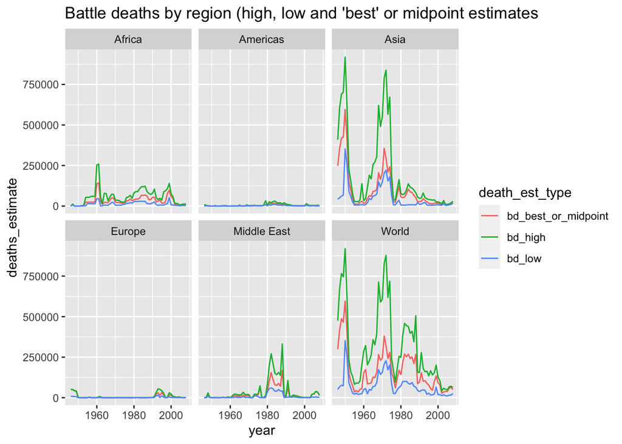

```r
df_prio_agg_full %>%
  filter(type == "All state-based conflict types") %>%
  ggplot(aes(x= year, y = deaths_estimate, colour = death_est_type)) +
  geom_line() +
  facet_wrap(~region) +
  ggtitle("Battle deaths by region (high, low and 'best' or midpoint estimates")
```

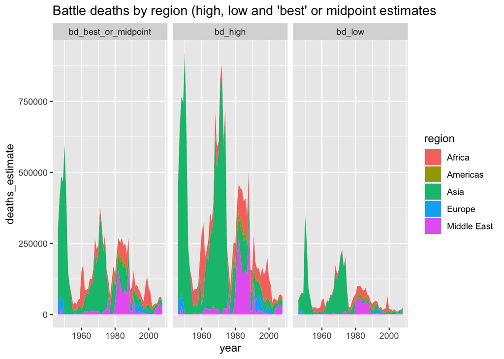

```r
df_prio_agg_full %>%
  filter(type == "All state-based conflict types",
         region != "World") %>%
  ggplot(aes(x= year, y = deaths_estimate, fill = region)) +
  geom_area() +
  facet_wrap(~death_est_type) +
  ggtitle("Battle deaths by region (high, low and 'best' or midpoint estimates")
```

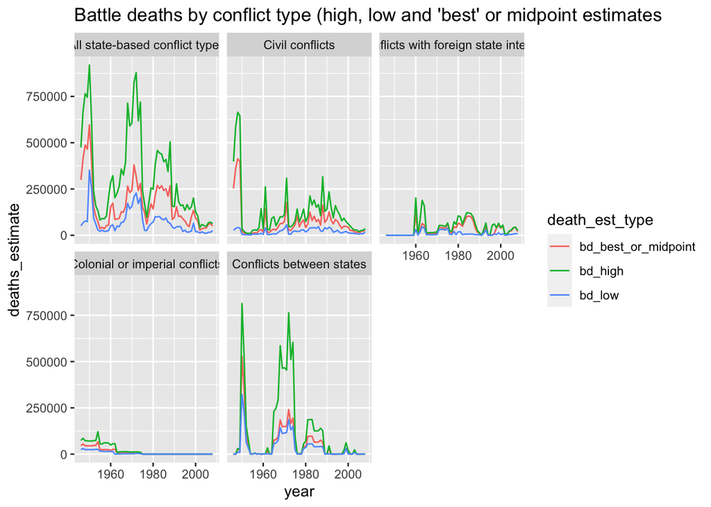

```r
df_prio_agg_full %>%
  filter(region == "World") %>%
  ggplot(aes(x= year, y = deaths_estimate, colour = death_est_type)) +
  geom_line() +
  facet_wrap(~type) +
  ggtitle("Battle deaths by conflict type (high, low and 'best' or midpoint estimates")
```

### UCDP Battle-Related Deaths data from 1989

(See codebook: https://ucdp.uu.se/downloads/brd/ucdp-brd-codebook-211.pdf)

Note that this is the same dataset that we pulled in earlier in the context of the post-1989 data. But I’ll pull it in again here to make it clear what’s going on.

```r
df_ucdp_brd<- read.csv("original/UCDP Yearly datasets since 1989/ucdp-brd-dyadic-211.csv")
```

Rename some variables to make the matching with the earlier PRIO data more straightforward.

```r
df_ucdp_brd<- df_ucdp_brd %>%
  rename(type = type_of_conflict)
```

This dataset is organised in almost exactly the same way as the earlier PRIO data, with two notable differences:

1. Best estimates for deaths are always available (there are no NA or negative observations)

```r
sum(is.na(df_ucdp_brd$bd_best))
```

```
## [1] 0
```

```r
min(df_ucdp_brd$bd_best)
```

```
## [1] 25
```

2. For a couple of observations, more than one region is coded (and for that reason `region` is a string variable in this dataset). I separate these out here:

```r
# Region code is stored as string. A string length>1 means more than one region is coded.
multi_region_conflicts<- df_ucdp_brd %>%
  filter(nchar(region)>1)

single_region_conflicts<- df_ucdp_brd %>%
  filter(nchar(region)==1)

  kable(multi_region_conflicts)
```

| conflict_id | dyad_id | location_inc | side_a | side_a_id | side_a_2nd | side_b | side_b_id | side_b_2nd | incompatibility | territory_name | year | bd_best | bd_low | bd_high | type | battle_location | gwno_a | gwno_a_2nd | gwno_b | gwno_b_2nd | gwno_loc | gwno_battle | region | version |
| --- | --- | --- | --- | --- | --- | --- | --- | --- | --- | --- | --- | --- | --- | --- | --- | --- | --- | --- | --- | --- | --- | --- | --- | --- |
| 13692 | 11199 | Afghanistan, United Kingdom, United States of America | Government of Afghanistan | 130 |  | Government of United Kingdom, Government of United States of America | 28, 3 |  | 2 |  | 2001 | 1397 | 1388 | 2075 | 2 | Afghanistan | 700 |  | 200, 2 |  | 2, 200, 700 | 700 | 1, 3, 5 | 21.1 |
| 420 | 883 | Australia, Iraq, United Kingdom, United States of America | Government of Australia, Government of United Kingdom, Government of United States of America | 156, 28, 3 |  | Government of Iraq | 116 |  | 2 |  | 2003 | 7927 | 7927 | 13814 | 2 | Iraq | 900, 200, 2 |  | 645 |  | 2, 200, 645, 900 | 645 | 1, 2, 3, 5 | 21.1 |

```r
#  a blank dataframe to append the data for individual conflicts with multiple regions
df_multi_region_conflicts_by_region<- data.frame(year = numeric(),
                                                 region = numeric(),
                                                 type = numeric(),
                                                 bd_best = numeric(),
                                                 bd_low = numeric(),
                                                 bd_high = numeric())

# for each conflict with multiple regions make a new df with one row per region, assuming that deaths are evenly split across the regions
for(this_id in unique(multi_region_conflicts$conflict_id)){

    this_conflict<- multi_region_conflicts %>%
    filter(conflict_id == this_id)

  regions_vector<- this_conflict %>%
    select(region) %>%
    as.character() %>%
    strsplit(", ") %>%
    unlist() %>%
    as.numeric()

  df_this_conflict_by_region<- data.frame(region = regions_vector)

  df_this_conflict_by_region<- df_this_conflict_by_region %>%
    mutate(year =  this_conflict %>%
                      select(year) %>%
                      as.numeric(),
                  type = this_conflict %>%
                                        select(type) %>%
                                        as.numeric(),
                   bd_best = (this_conflict %>%
                                        select(bd_best) %>%
                                        as.numeric())/length(regions_vector),
                   bd_low = (this_conflict %>%
                                        select(bd_low) %>%
                                        as.numeric())/length(regions_vector),
                   bd_high = (this_conflict %>%
                                        select(bd_high) %>%
                                        as.numeric())/length(regions_vector))

  df_multi_region_conflicts_by_region<- rbind(df_multi_region_conflicts_by_region, df_this_conflict_by_region)
}
```

Add the multi-region conflicts back in with the rest (dropping unnecessary columns)

```r
# convert region to numeric format
single_region_conflicts<- single_region_conflicts %>%
  mutate(region = as.integer(region))

df_ucdp_brd_unmixed_regions<- rbind(
  subset(single_region_conflicts, select = colnames(df_multi_region_conflicts_by_region)),
  df_multi_region_conflicts_by_region
)
```

### Aggregate deaths at the year region and conflict type levels.

Again I’ll produce 3 different aggregations: 1) using the low deaths estimate always, 2) using the high deaths estimate always, 3) using the best estimate (in this dataset this is available for all observations).

```r
# Aggregate high, low and 'best' deaths estimates by year, region and conflict type
df_ucdp_brd_agg<- df_ucdp_brd_unmixed_regions %>%
  group_by(year, region, type) %>%
  summarise(bd_low = sum(bd_low),
            bd_high = sum(bd_high),
            bd_best = sum(bd_best))
# stack to long-format
df_ucdp_brd_agg<- df_ucdp_brd_agg %>%
  pivot_longer(cols =  c(bd_low, bd_high, bd_best),
               names_to = "death_est_type",
               values_to = "deaths_estimate")
```

As with the other datasets in this notebook, because the data measures the presence (rather than absence) of conflict deaths, region-type-year observations will be missing where there were no conflict deaths. We want these included as zeros, rather than missing.

I make a complete set of region-type-year observations of zero, and then merge and replace in the actual data.

```r
regions <-  c(1,2,3,4,5)
types <- c(1,2,3,4) # note that the UCDP BRD has no type 1 (colonial/imperial) conflicts in it.
years <- seq(from=min(df_ucdp_brd_agg$year), to=max(df_ucdp_brd_agg$year))
death_est_type <- c("bd_low", "bd_high", "bd_best")


# Calling expand.grid() Function to fill out all permutations
df_ucdp_brd_agg_full<- expand.grid(years, types, regions, death_est_type)

# rename columns as per actual data
names(df_ucdp_brd_agg_full)<- c("year", "type", "region", "death_est_type")

# merge in recorded aggregates from data and replace NA with zeros
df_ucdp_brd_agg_full<- left_join(df_ucdp_brd_agg_full, df_ucdp_brd_agg) %>%
  mutate(deaths_estimate = replace_na(deaths_estimate, 0))
```

Give region and conflict type codes understandable labels

```r
df_ucdp_brd_agg_full<- df_ucdp_brd_agg_full %>%
 mutate(type = recode(type,
                  `1` = "Colonial or imperial conflicts", # Extrasystemic
                  `2` = "Conflicts between states", # interstate
                  `3` = "Civil conflicts", # intrastate
                  `4` = "Civil conflicts with foreign state intervention" #  internationalized intrastate
                 ))


df_ucdp_brd_agg_full<- df_ucdp_brd_agg_full %>%
 mutate(region = recode(region,
                  `1` = "Europe",
                  `2` = "Middle East",
                  `3` = "Asia",
                  `4` = "Africa",
                  `5` = "Americas"
                 ))
```

Calculate aggregate ‘All state-based conflict types’ type and merge back in

```r
df_ucdp_brd_agg_full_all_types<- df_ucdp_brd_agg_full %>%
  group_by(year, death_est_type, region) %>%
  summarise(deaths_estimate = sum(deaths_estimate)) %>%
  mutate(type = "All state-based conflict types")
df_ucdp_brd_agg_full<- rbind(df_ucdp_brd_agg_full, df_ucdp_brd_agg_full_all_types)
```

Calculate aggregate World entity and merge back in

```r
df_ucdp_brd_agg_world<- df_ucdp_brd_agg_full %>%
  group_by(year, death_est_type, type) %>%
  summarise(deaths_estimate = sum(deaths_estimate)) %>%
  mutate(region = "World")
df_ucdp_brd_agg_full<- rbind(df_ucdp_brd_agg_full, df_ucdp_brd_agg_world)
```

Some plots to sense check

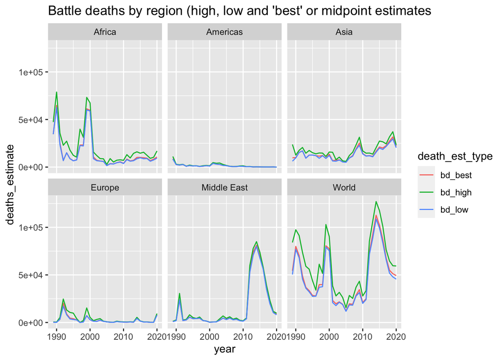

```r
df_ucdp_brd_agg_full %>%
  filter(type == "All state-based conflict types") %>%
  ggplot(aes(x= year, y = deaths_estimate, colour = death_est_type)) +
  geom_line() +
  facet_wrap(~region) +
  ggtitle("Battle deaths by region (high, low and 'best' or midpoint estimates")
```

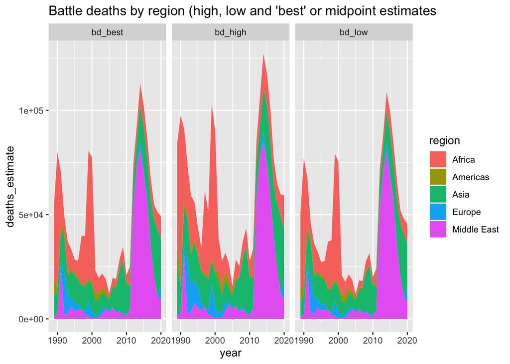

```r
df_ucdp_brd_agg_full %>%
  filter(type == "All state-based conflict types",
         region != "World") %>%
  ggplot(aes(x= year, y = deaths_estimate, fill = region)) +
  geom_area() +
  facet_wrap(~death_est_type) +
  ggtitle("Battle deaths by region (high, low and 'best' or midpoint estimates")
```

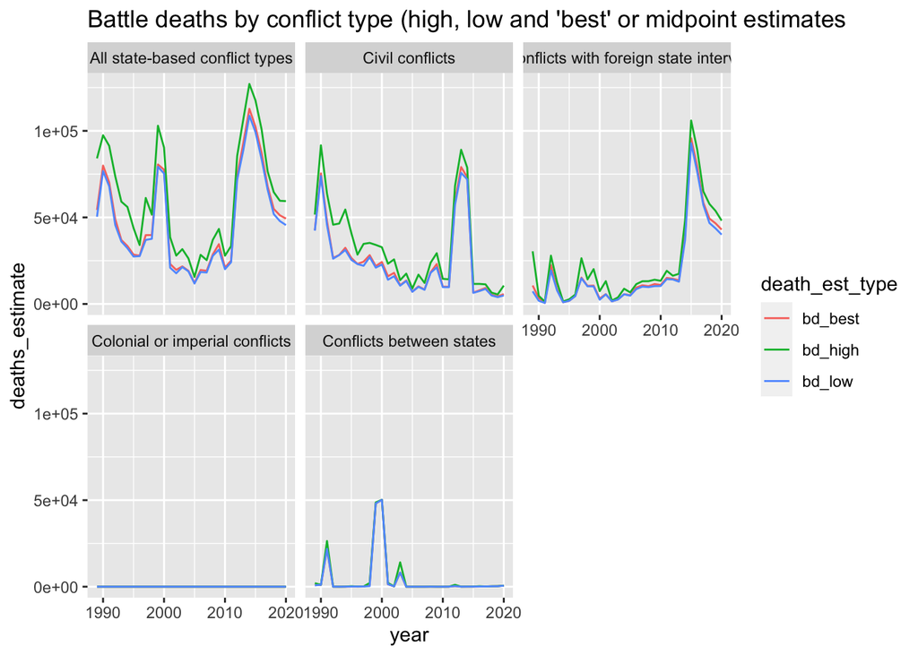

```r
df_ucdp_brd_agg_full %>%
  filter(region == "World") %>%
  ggplot(aes(x= year, y = deaths_estimate, colour = death_est_type)) +
  geom_line() +
  facet_wrap(~type) +
  ggtitle("Battle deaths by conflict type (high, low and 'best' or midpoint estimates")
```

### Stitch together the two PRIO and UCDP BRD datasets (cutoff is at 1989)

As a sense check, lets plot the two together. We see that the trends are similar, but there are differences.

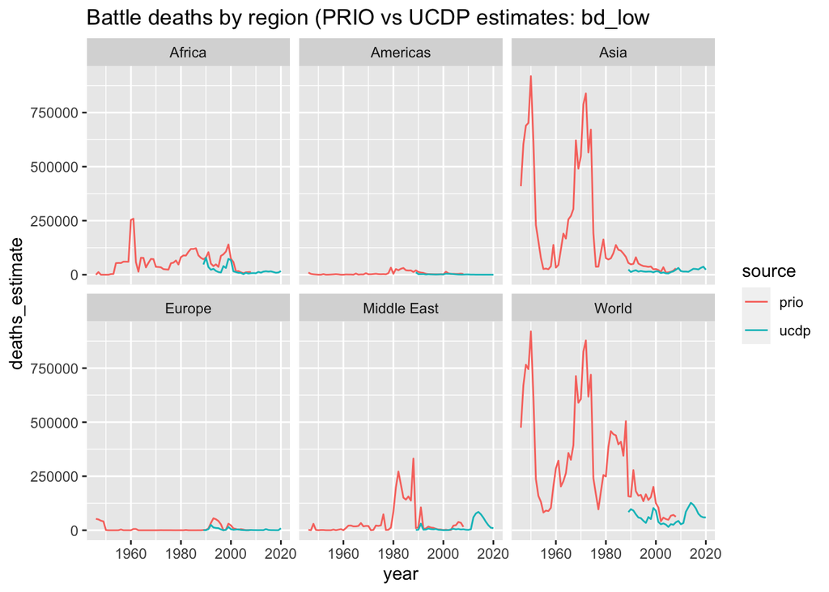

```r
df_prio_agg_full<- df_prio_agg_full %>%
  mutate(source = "prio")

# rename the best deaths estimates type in UCDP data to match PRIO
df_ucdp_brd_agg_full<- df_ucdp_brd_agg_full %>%
  mutate(death_est_type = if_else(death_est_type == "bd_best",
                                  "bd_best_or_midpoint",
                                  death_est_type)) %>%
  mutate(source = "ucdp")

df_agg_both_sources<- rbind(df_prio_agg_full,df_ucdp_brd_agg_full )

# Plot
df_agg_both_sources %>%
  filter(type == "All state-based conflict types",
         death_est_type == "bd_high") %>% # Change to bd_low, bd_high or bd_best_or_midpoint
  ggplot(aes(x= year, y = deaths_estimate, colour = source)) +
  geom_line() +
  facet_wrap(~region) +
  ggtitle(paste0("Battle deaths by region (PRIO vs UCDP estimates: ",death_est_type))
```

Stitch together, dropping PRIO after 1989

```r
df_agg_both_sources<- df_agg_both_sources %>%
  filter(!(source=="prio" & year>=1989)) %>%
  select(-source)
```

Some plots to sense check

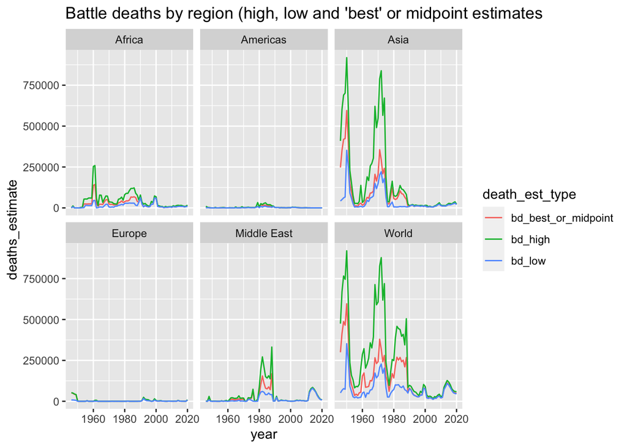

```r
df_agg_both_sources %>%
  filter(type == "All state-based conflict types") %>%
  ggplot(aes(x= year, y = deaths_estimate, colour = death_est_type)) +
  geom_line() +
  facet_wrap(~region) +
  ggtitle("Battle deaths by region (high, low and 'best' or midpoint estimates")
```

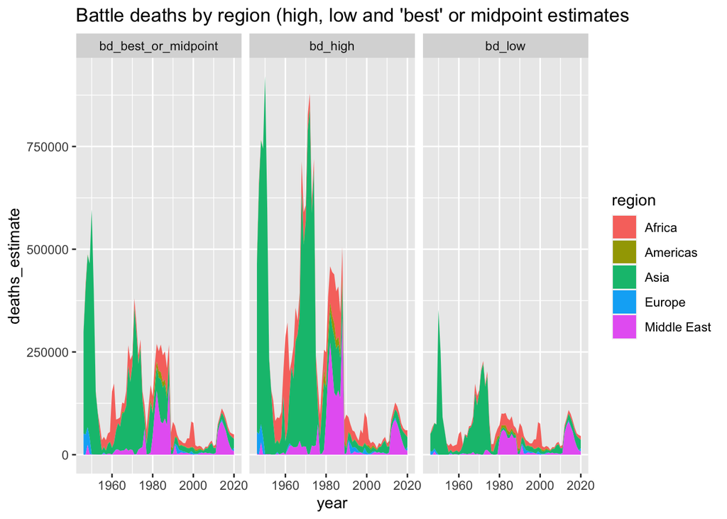

```r
df_agg_both_sources %>%
  filter(type == "All state-based conflict types",
         region != "World") %>%
  ggplot(aes(x= year, y = deaths_estimate, fill = region)) +
  geom_area() +
  facet_wrap(~death_est_type) +
  ggtitle("Battle deaths by region (high, low and 'best' or midpoint estimates")
```

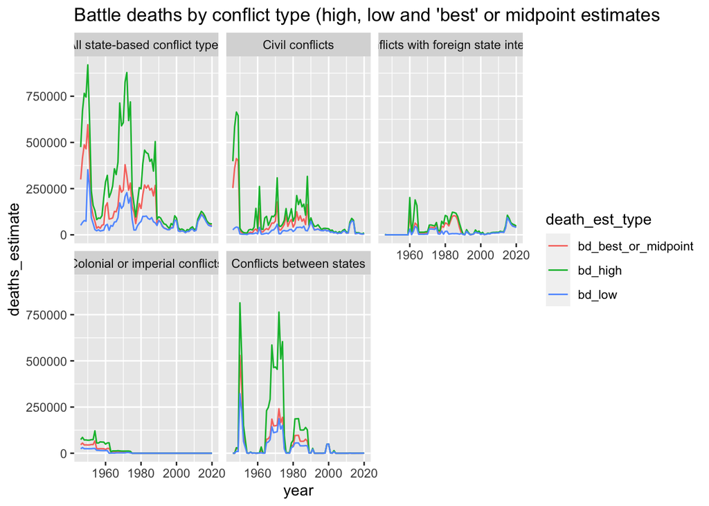

```r
df_agg_both_sources %>%
  filter(region == "World") %>%
  ggplot(aes(x= year, y = deaths_estimate, colour = death_est_type)) +
  geom_line() +
  facet_wrap(~type) +
  ggtitle("Battle deaths by conflict type (high, low and 'best' or midpoint estimates")
```

#### Export aggrgeated state-based data for OWID grapher

For the time being, I’ll only upload the ‘best or midpoint’ data. But my plan is to add visualizations showing the range between the low, high and best/midpoint estimates.

Filter fot he best/midpoint estimates and then spread to wide format where each variable is the the deaths estimate for a type of conflict.

```r
df_agg_both_sources<- df_agg_both_sources %>%
  filter(death_est_type == "bd_best_or_midpoint") %>%
  mutate(type = paste0("Deaths in ", tolower(type))) %>%
  pivot_wider(names_from = "type", values_from = "deaths_estimate") %>%
  select(-death_est_type) %>%
  rename(entity = region)
```

Export as csv

```r
write.csv(df_agg_both_sources, "output/State-based conflict deaths since 1946, by region and conflict type (PRIO and UCDP).csv", row.names = FALSE)
```